# Regresión lineal Datos Vino

## Preliminares

En este documento ajustaremos algunos modelos de regresión lineal a los datos sobre venta de vinos. Para ello, utilizamos el conjunto de datos que generamos tras la depuración, asegurando un conjunto de datos “limpios” y exentos de ciertos peligros.

En primer lugar se fija el directorio de trabajo donde tenemos las funciones y los datos.

Procedemos a la lectura de los datos depurados. Ya que vamos a hacer cosas como evaluación de las relaciones entre los predictores y la respuesta o creación masiva de transformaciones para< conseguir linealidad, lo mejor es separar las respuestas y quedarnos con el input depurado, de esta forma podemos aplicar una misma función a todo el conjunto sin peligro de transformar las respuestas y cosas raras que puedan suceder.

```r
# Parto de los datos sin atípicos ni ausentes guardados
datos<-readRDS("F:/Documentos/Master Comercio 2021-22/PARTE I_Depuracion y Regresiones/Dia1_MD&Depuracion/datosVinoDep")

varObjCont<-datos$varObjCont
varObjBin<-datos$varObjBin
input<-datos[,-(1:2)]
```

No es mala idea generar un par de variables de “control” para la evaluación de los efectos de los predictores frente a la respuesta. La idea es la siguiente: si generamos variables en el más estricto sentido aleatorio (por ejemplo siguiendo una distribución uniforme[0,1]) cualquier relación que estas presenten con la variable respuesta serán debidas puramente al azar, con lo que se pueden considerar relaciones espurias, es decir, falsas.

Por tanto, ya sea en la inspección preliminar de relaciones con la respuesta mediante correlación (relación lineal, válido para continua-continua) o VCramer (asociación en tablas de contingencia, válido para cruce de variables categóricas/nominales o continuas tramificadas) o bien en los propios modelos de regresión, las variables que presenten una menor relación con la respuesta que las variables de control, tendrán una sombra de sospecha sobre la veracidad de esa relación y probablemente serán descartadas, al menos en su estado original (siempre se pueden tratar de transformar, tramificar etc)

```r
# Creo la variable aleatoria
input$aleatorio<-runif(nrow(input))

input$aleatorio2<-runif(nrow(input))
```

## Estudio descriptivo de relaciones con la respuesta

En este apartado intentaremos descubrir a priori las relaciones marginales de las variables con la variable objetivo para hacernos una idea de cuales de ellas serán potencialmente influyentes en los modelos de regresión que ajustemos.

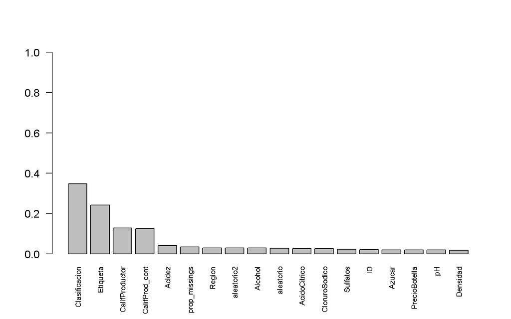

```r
#Obtengo la importancia de las variables.
# Falla si hay alguna variable cuantitativa
# con menos de 6 valores diferentes
graficoVcramer(input,varObjCont)
```

Aparecen las nominales y también prop_missings (algo que comprobaremos luego en modelo). A partir de acidez…las relaciones no son más fuertes que las debidas al azar (al menos a nivel marginal). Sospechamos que las demás variables tendrán baja influencia a no ser que se produzca efecto potenciador por la presencia conjunta de varios efectos en un mismo modelo (cosa que valoraremos llegado el momento).

Vamos a ver gráficamente las relaciones de las nominales sobre la continua. Podemos hacer uso del boxplot e histograma para target binaria ya que en realidad tiene implementado una comparación de continua con categórica en gráfico. En este caso lo utilizaremos de manera inversa al especificado en la fórmula de la función, indicando primero la objetivo continua y luego la nominal del input.

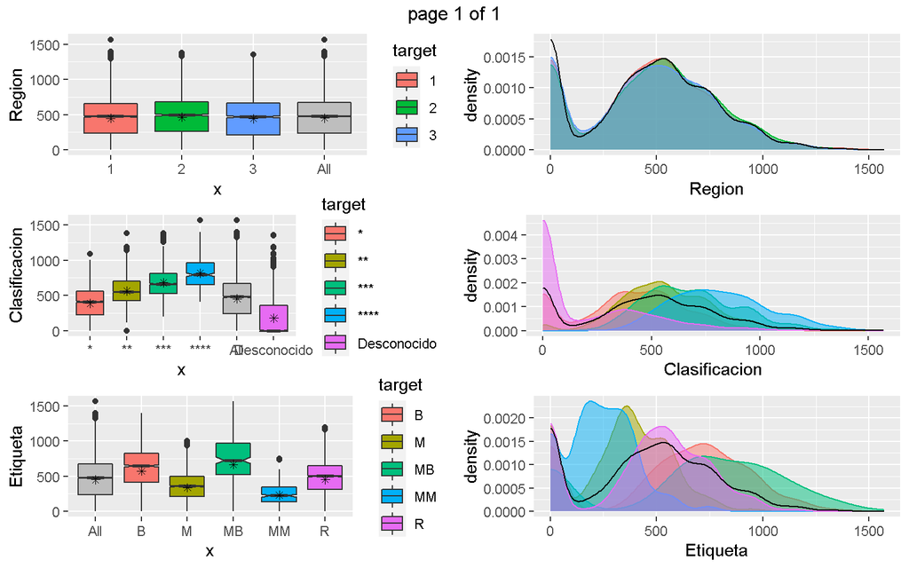

```r
#Veo gráficamente el efecto de dos variables cualitativas sobre la binaria
b1<-boxplot_targetbinaria(varObjCont,input$Region,"Region") #esta no influye
b2<-boxplot_targetbinaria(varObjCont,input$Clasificacion,"Clasificacion") #esta sí influye
b3<-boxplot_targetbinaria(varObjCont,input$Etiqueta,"Etiqueta") #esta sí influye

h1<-hist_targetbinaria(varObjCont,input$Region,"Region") #esta no influye
h2<-hist_targetbinaria(varObjCont,input$Clasificacion,"Clasificacion") #esta sí influye
h3<-hist_targetbinaria(varObjCont,input$Etiqueta,"Etiqueta") #esta sí influye

marrangeGrob(list(b1,b2,b3,h1,h2,h3),nrow = 3,ncol = 2)
```

A la vista de los gráficos, es evidente que el solapamiento de las distribuciones del beneficio del vino en relación a la región de origen del mismo indica la falta de influencia de la variable región en dicho beneficio, por lo que diremos que este predictor no tiene capacidad de discriminación frente a la respuesta y no será importante para el modelo.

En cambio, las variables clasificación y Etiqueta presentan distribuciones de beneficio muy distintas en sus categorías, por lo que estas categorías pueden servir para estimar dicho beneficio. Sospechamos que serán importantes de cara al modelado.

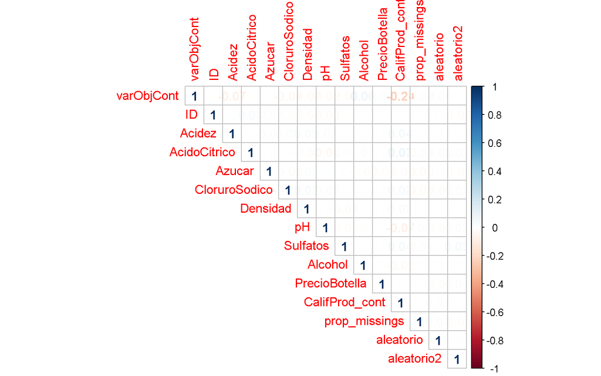

```r
# Gráfico de correlaciones entre las variables continuas
corrplot(cor(cbind(varObjCont,Filter(is.numeric, input)), use="pairwise", method="pearson"), method = "number",type = "upper")
```

En el gráfico de correlaciones se intuye la baja relación lineal presente entre las variables del archivo 2 a 2. Esto nos hace pensar que las variables continuas, a diferencia de las categóricas, no van a tener demasiada influencia en los modelos de regresión frente a la respuesta (véase el poco color que presenta la fila 1). Por otro lado, podemos estar respirar con cierta tranquilidad ante el hecho de la baja relación entre los predictores (véase la ausencia de color en todo el gráfico), cosa que evitará problemas de colinealidad en los modelos.

Es evidente que, las relaciones de cada variable con su transformada han de ser muy elevadas, ya que hay un mecanismo que genera una en función exacta de la otra, por lo que esto es normal.

**Nota:** La principal precaución que hay que tener es no considerar un modelo completo con todas al mismo tiempo puesto que se pueden generar los problemas de colinealidad. Solamente utilizaremos el set completo de variables cuando hagamos un proceso de selección automática de variables, proceso en el cual se elegirán las que más R2 aporten al modelo.

### Transformaciones de las variables continuas

El principal objetivo de las transformaciones de las variables continuas es conseguir linealidad frente a la variable objetivo. De esta forma se prueban las transformaciones típicas (log, exp, potencias y raíces) y se escoge aquella que mayor coeficiente de correlación presenta con la respuesta continua.

```r
#Busco las mejores transformaciones para las variables numéricas con respesto a los dos tipos de variables
input_cont<-cbind(input,Transf_Auto(Filter(is.numeric, input),varObjCont))

saveRDS(data.frame(input_cont,varObjCont),"todo_cont_Vino")
```

Podemos comprobar si las transformaciones han aumentado el valor de correlación lineal con la respuesta.

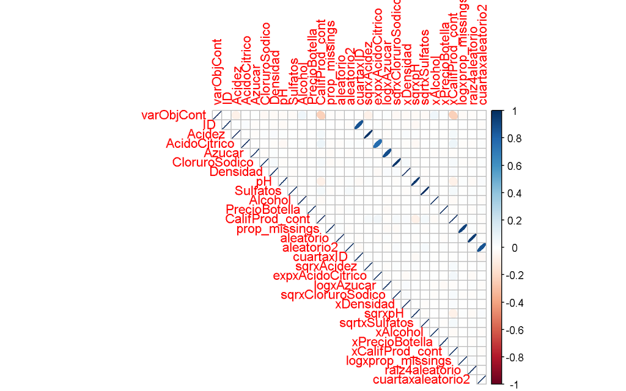

```r
# Gráfico de correlaciones entre las variables continuas (incluidas transformaciones)
corrplot(cor(cbind(varObjCont,Filter(is.numeric, input_cont)), use="pairwise", method="pearson"), method = "ellipse",type = "upper")
```

No parece que haya mejorado mucho…Este estudio nos lleva a pensar que las variables continuas no van a aportar mucho a nuestro modelo de regresión, si bien puede suceder que en presencia de otras variables (por ejemplo las categóricas) la influencia de éstas pueda aumentar debido al distinto comportamiento (pendiente) que presenten con la respuesta en los distintos grupos que forma la variable categórica.

Por este motivo, es positivo complementar este análisis descriptivo con la información que dan los modelos sobre la importancia de variables, ya que dentro de modelo, la influencia de la variable se entiende a niveles constantes de todas las demás presentes en el mismo.

En cualquier caso, una vía que se puede explorar aquí para conseguir mayor influencia de las continuas es intentar tramificarlas (pasarlas a categóricas) de tal manera que se puedan descubrir patrones muy alejados d la linealidad que esta puedan contener. En el mundo de la tramificación existen dos estrategias fundamentales,

1. tramos ad-hoc para una mejor interpretabilidad (por ejemplo tramos de edad acordes a los que se utilizan en las estadísticas oficiales) en los que normalmente se realizan particiones más o menos equidistantes o basadas en un fundamento anterior.
2. tramos que maximicen cierta relación con la variable objetivo. Se pueden generar los puntos de corte de la variable a tramificar tales que los grupos creados sean lo más distintos entre sí en distribución de la variable respuesta, con lo que se “aseguran” tramos con capacidad de discriminar frente al objetivo. Suelen funcionar bien este tipo de tramificaciones pero tienen cierto peligro de sobreajustar a los datos de entrenamiento…Una de las formas de hacerlo es mediante árboles de regresión/clasificación.

Un árbol realiza particiones binarias de las variables con la premisa de encontrar las mayores diferencias entre los grupos que va formando, justo lo que buscamos!

```r
# Arbol para tramificar azucar
tree_azucar<-rpart::rpart(varObjCont~Azucar, data = datos, cp=0.005)
tree_azucar
```

```
## n= 6365
##
## node), split, n, deviance, yval
##       * denotes terminal node
##
## 1) root 6365 605207200 452.3802
##   2) Azucar< 4.4521 3248 324062600 435.8534
##     4) Azucar>=1.6295 977 110549100 370.9898 *
##     5) Azucar< 1.6295 2271 207634600 463.7583 *
##   3) Azucar>=4.4521 3117 279333100 469.6015 *
```

Vamos a crear la variable que propone el árbol, categórica con 3 niveles y los puntos de corte comentados. el argumento where del árbol contiene esta variable, pero sin las etiquetas apropiadas. Comprobamos y ponemos las correctas.

```r
# puntos de corte en 1.61 y 4.46. Tres grupos.
table(tree_azucar$where)
```

```
##
##    3    4    5
##  977 2271 3117
```

```r
# Los grupos están ya ordenados pero se llaman 3 4 y 5

# Añadimos la variable tramificada al dataset
input$Azucar_tree<-factor(tree_azucar$where)
```

**NOTA**: Aquí hay una errata en la asignación del verdadero nombre de los niveles del factor. Es bueno fijarse en la cantidad de observaciones de cada nivel. En nuestro caso tenemos que por debajo de nivel de azucar 1.62 tenemos 2271 observaciones, entre 1.62 y 4.45 tenemos 977 y en el rango de valores superiores tenemos 3117. Con lo cual parece que:

- El nivel llamado 3 corresponde con el rango de valores 1.62-4.45
- El nivel llamado 4 corresponde a <1.62
- El nivel llamado 5 es en realidad el rango >4.45

```r
# Cambiamos los niveles (los ordeno correctamente!!)
levels(input$Azucar_tree) = c('1.62-4.45','<1.62','>4.45')

# Comprobamos
table(input$Azucar_tree)
```

```
##
## 1.62-4.45     <1.62     >4.45
##       977      2271      3117
```

```r
# Ordenamos niveles
input$Azucar_tree<-factor(input$Azucar_tree, levels = c('<1.62','1.62-4.45','>4.45'))

# Comprobamos
table(input$Azucar_tree)
```

```
##
##     <1.62 1.62-4.45     >4.45
##      2271       977      3117
```

Vamos a valorar la capacidad a priori de esta variable.

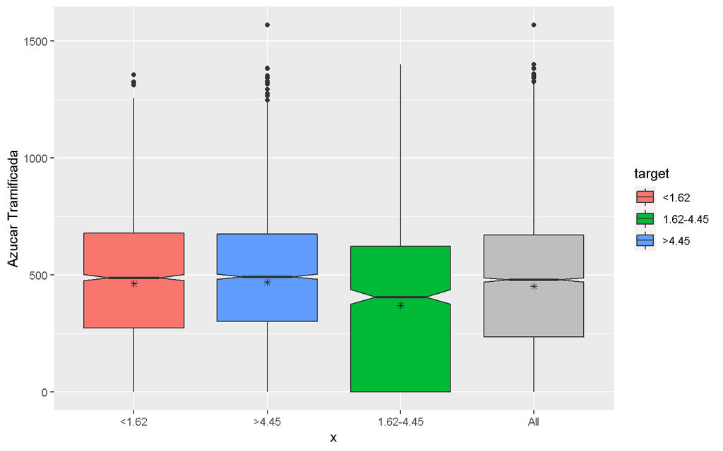

```r
boxplot_targetbinaria(varObjCont,input$Azucar_tree,"Azucar Tramificada")
```

El tramo de valores intermedios es claramente distinto a los otros. Existe cierta diferencia entre el 2 y el 3los extremos pero no queda claro si será significativa. Habrá que valorarlo en modelo.

## Modelos de regresión lineal para la predicción del beneficio del vino

En esta sección se ajustan distintos modelos de regresión lineal para predecir el beneficio de los vinos. En primer lugar tomamos la partición training (donde ajustamos el modelo) y test (donde probamos su capacidad).

### Partición training-test

```r
## Comienzo con la regresión lineal
todo<-data.frame(input,varObjCont)

#Obtengo la partición
set.seed(123456)
trainIndex <- createDataPartition(todo$varObjCont, p=0.8, list=FALSE)
data_train <- todo[trainIndex,]
data_test <- todo[-trainIndex,]
```

### Modelo completo de referencia

Probamos primero con las variables continuas de erigen para las que tenemos otras posibilidades contempladas, en este caso Azucar y Calif_Prod.

```r
#Construyo un modelo preliminar con todas las variables
modelo1<-lm(varObjCont~.- Azucar_tree- CalifProductor-ID ,data=data_train)
summary(modelo1)
```

```
##
## Call:
## lm(formula = varObjCont ~ . - Azucar_tree - CalifProductor -
##     ID, data = data_train)
##
## Residuals:
##     Min      1Q  Median      3Q     Max
## -665.96 -162.89  -17.25  148.17  962.44
##
## Coefficients:
##                            Estimate Std. Error t value Pr(>|t|)
## (Intercept)               655.35410  138.14752   4.744 2.15e-06 ***
## Acidez                    -16.20313    4.44633  -3.644 0.000271 ***
## AcidoCitrico                1.30471    4.08965   0.319 0.749718
## Azucar                      0.09922    0.10269   0.966 0.333982
## CloruroSodico             -32.29010   10.76483  -3.000 0.002717 **
## Densidad                  -76.47666  136.66173  -0.560 0.575773
## pH                         -8.59402    5.15443  -1.667 0.095515 .
## Sulfatos                   -0.31393    3.70989  -0.085 0.932568
## Alcohol                     2.11318    0.90597   2.333 0.019712 *
## EtiquetaM                -138.02331    9.38242 -14.711  < 2e-16 ***
## EtiquetaMB                 60.85552   17.48629   3.480 0.000505 ***
## EtiquetaMM               -207.98253   17.40247 -11.951  < 2e-16 ***
## EtiquetaR                 -75.18186    8.16417  -9.209  < 2e-16 ***
## Clasificacion**           141.17605    8.86811  15.920  < 2e-16 ***
## Clasificacion***          240.26816   10.30202  23.322  < 2e-16 ***
## Clasificacion****         332.25096   16.23096  20.470  < 2e-16 ***
## ClasificacionDesconocido -216.31368    8.96577 -24.127  < 2e-16 ***
## Region2                     3.08046    7.76926   0.396 0.691757
## Region3                     3.56356    7.68890   0.463 0.643048
## PrecioBotella               0.41110    2.11753   0.194 0.846074
## CalifProd_cont            -31.72206    2.45143 -12.940  < 2e-16 ***
## prop_missings             -11.65806   75.71245  -0.154 0.877633
## aleatorio                   6.28519   11.00588   0.571 0.567974
## aleatorio2                 -1.11670   10.92226  -0.102 0.918570
## ---
## Signif. codes:  0 '***' 0.001 '**' 0.01 '*' 0.05 '.' 0.1 ' ' 1
##
## Residual standard error: 224.4 on 5070 degrees of freedom
## Multiple R-squared:  0.4732, Adjusted R-squared:  0.4708
## F-statistic:   198 on 23 and 5070 DF,  p-value: < 2.2e-16
```

```r
Rsq(modelo1,"varObjCont",data_train)
```

```
## $r2
## [1] 0.4731936
##
## $r2_adj
## [1] 0.4706994
```

```r
Rsq(modelo1,"varObjCont",data_test)
```

```
## $r2
## [1] 0.4805893
##
## $r2_adj
## [1] 0.4705846
```

```r
modelo1_t<-lm(varObjCont~.- Azucar- CalifProductor-ID,data=data_train)
summary(modelo1_t)
```

```
##
## Call:
## lm(formula = varObjCont ~ . - Azucar - CalifProductor - ID, data = data_train)
##
## Residuals:
##     Min      1Q  Median      3Q     Max
## -671.70 -162.06  -17.99  147.59  959.15
##
## Coefficients:
##                           Estimate Std. Error t value Pr(>|t|)
## (Intercept)               673.1503   137.9895   4.878  1.1e-06 ***
## Acidez                    -15.6633     4.4410  -3.527 0.000424 ***
## AcidoCitrico                0.8602     4.0842   0.211 0.833190
## CloruroSodico             -31.1484    10.7515  -2.897 0.003782 **
## Densidad                  -97.1428   136.5723  -0.711 0.476936
## pH                         -8.1152     5.1472  -1.577 0.114943
## Sulfatos                    0.1355     3.7052   0.037 0.970839
## Alcohol                     2.2095     0.9049   2.442 0.014651 *
## EtiquetaM                -137.1019     9.3682 -14.635  < 2e-16 ***
## EtiquetaMB                 61.3356    17.4570   3.514 0.000446 ***
## EtiquetaMM               -207.9885    17.3736 -11.972  < 2e-16 ***
## EtiquetaR                 -74.4777     8.1501  -9.138  < 2e-16 ***
## Clasificacion**           140.7631     8.8533  15.900  < 2e-16 ***
## Clasificacion***          240.4582    10.2855  23.378  < 2e-16 ***
## Clasificacion****         332.7129    16.2080  20.528  < 2e-16 ***
## ClasificacionDesconocido -214.4416     8.9618 -23.928  < 2e-16 ***
## Region2                     3.1728     7.7568   0.409 0.682529
## Region3                     3.4833     7.6775   0.454 0.650060
## PrecioBotella               0.5035     2.1142   0.238 0.811753
## CalifProd_cont            -30.7545     2.4586 -12.509  < 2e-16 ***
## prop_missings              -9.1132    75.5749  -0.121 0.904025
## aleatorio                   5.8103    10.9893   0.529 0.597019
## aleatorio2                 -1.5644    10.9081  -0.143 0.885966
## Azucar_tree1.62-4.45      -34.6577     9.6546  -3.590 0.000334 ***
## Azucar_tree>4.45            4.6151     6.9416   0.665 0.506178
## ---
## Signif. codes:  0 '***' 0.001 '**' 0.01 '*' 0.05 '.' 0.1 ' ' 1
##
## Residual standard error: 224.1 on 5069 degrees of freedom
## Multiple R-squared:  0.475,  Adjusted R-squared:  0.4725
## F-statistic: 191.1 on 24 and 5069 DF,  p-value: < 2.2e-16
```

```r
Rsq(modelo1_t,"varObjCont",data_train)
```

```
## $r2
## [1] 0.4750142
##
## $r2_adj
## [1] 0.4724245
```

```r
Rsq(modelo1_t,"varObjCont",data_test)
```

```
## $r2
## [1] 0.4864374
##
## $r2_adj
## [1] 0.4761249
```

El modelo mejora en todo, R2 ajustado (a pesar del aumento de 1 parámetro), significación de la variable y capacidad de generalización al test. Elegiremos quedarnos con esta variable tramificada en lugar de la original.

```r
# Nos fijamos en la importancia de las variables. Podemos sacar un gráfico
# que muestra lo que se pierde en R2 en train al quitarlas del modelo
modelEffectSizes(modelo1_t)
```

```
## lm(formula = varObjCont ~ . - Azucar - CalifProductor - ID, data = data_train)
##
## Coefficients
##                         SSR df pEta-sqr dR-sqr
## (Intercept)    1.194865e+06  1   0.0047     NA
## Acidez         6.245810e+05  1   0.0024 0.0013
## AcidoCitrico   2.227401e+03  1   0.0000 0.0000
## CloruroSodico  4.214219e+05  1   0.0017 0.0009
## Densidad       2.540290e+04  1   0.0001 0.0001
## pH             1.248096e+05  1   0.0005 0.0003
## Sulfatos       6.710370e+01  1   0.0000 0.0000
## Alcohol        2.993551e+05  1   0.0012 0.0006
## Etiqueta       1.689185e+07  4   0.0622 0.0348
## Clasificacion  1.438401e+08  4   0.3611 0.2967
## Region         1.253089e+04  2   0.0000 0.0000
## PrecioBotella  2.848311e+03  1   0.0000 0.0000
## CalifProd_cont 7.856238e+06  1   0.0299 0.0162
## prop_missings  7.300839e+02  1   0.0000 0.0000
## aleatorio      1.403613e+04  1   0.0001 0.0000
## aleatorio2     1.032737e+03  1   0.0000 0.0000
## Azucar_tree    9.296554e+05  2   0.0036 0.0019
##
## Sum of squared errors (SSE): 254512541.4
## Sum of squared total  (SST): 484798924.6
```

```
## lm(formula = varObjCont ~ . - Azucar - CalifProductor - ID, data = data_train)
##
## Coefficients
##                         SSR df pEta-sqr dR-sqr
## (Intercept)    1.194865e+06  1   0.0047     NA
## Acidez         6.245810e+05  1   0.0024 0.0013
## AcidoCitrico   2.227401e+03  1   0.0000 0.0000
## CloruroSodico  4.214219e+05  1   0.0017 0.0009
## Densidad       2.540290e+04  1   0.0001 0.0001
## pH             1.248096e+05  1   0.0005 0.0003
## Sulfatos       6.710370e+01  1   0.0000 0.0000
## Alcohol        2.993551e+05  1   0.0012 0.0006
## Etiqueta       1.689185e+07  4   0.0622 0.0348
## Clasificacion  1.438401e+08  4   0.3611 0.2967
## Region         1.253089e+04  2   0.0000 0.0000
## PrecioBotella  2.848311e+03  1   0.0000 0.0000
## CalifProd_cont 7.856238e+06  1   0.0299 0.0162
## prop_missings  7.300839e+02  1   0.0000 0.0000
## aleatorio      1.403613e+04  1   0.0001 0.0000
## aleatorio2     1.032737e+03  1   0.0000 0.0000
## Azucar_tree    9.296554e+05  2   0.0036 0.0019
##
## Sum of squared errors (SSE): 254512541.4
## Sum of squared total  (SST): 484798924.6
```

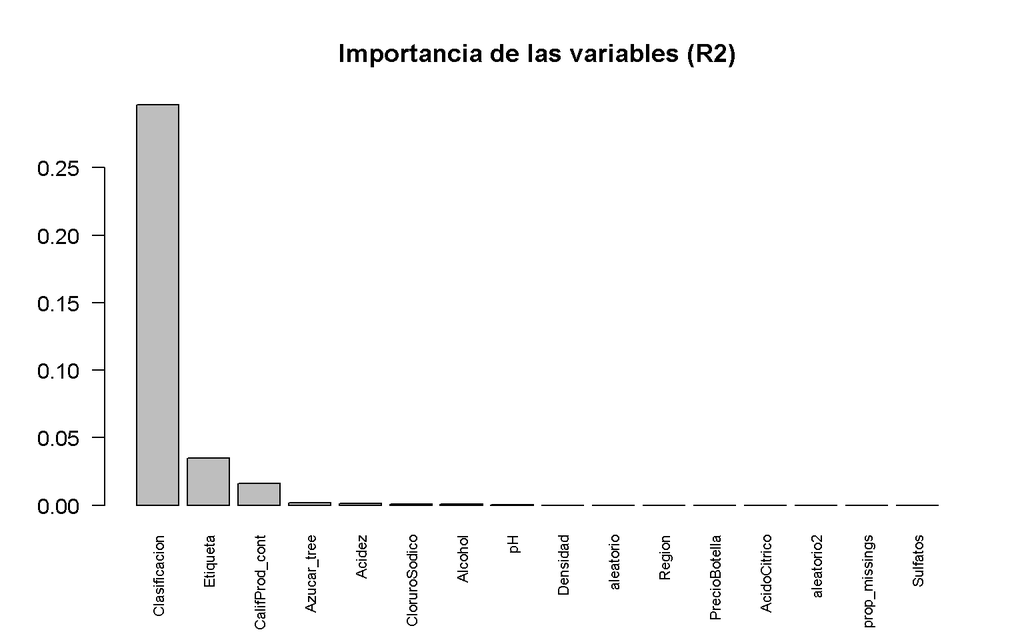

```r
barplot(sort(modelEffectSizes(modelo1_t)$Effects[-1,4],decreasing =T),las=2, cex.names = 0.7,main="Importancia de las variables (R2)")
```

### Modelo con las variables más importantes según Vcramer

```r
modelo2<-lm(varObjCont~Clasificacion+Etiqueta+CalifProd_cont+prop_missings,data=data_train)
summary(modelo2)
```

```
##
## Call:
## lm(formula = varObjCont ~ Clasificacion + Etiqueta + CalifProd_cont +
##     prop_missings, data = data_train)
##
## Residuals:
##     Min      1Q  Median      3Q     Max
## -681.76 -163.70  -16.31  148.90  968.73
##
## Coefficients:
##                          Estimate Std. Error t value Pr(>|t|)
## (Intercept)               573.571     11.845  48.423  < 2e-16 ***
## Clasificacion**           142.766      8.862  16.110  < 2e-16 ***
## Clasificacion***          242.361     10.299  23.533  < 2e-16 ***
## Clasificacion****         336.750     16.220  20.762  < 2e-16 ***
## ClasificacionDesconocido -217.325      8.969 -24.231  < 2e-16 ***
## EtiquetaM                -137.847      9.394 -14.674  < 2e-16 ***
## EtiquetaMB                 62.012     17.500   3.544 0.000398 ***
## EtiquetaMM               -207.520     17.409 -11.920  < 2e-16 ***
## EtiquetaR                 -74.396      8.174  -9.101  < 2e-16 ***
## CalifProd_cont            -31.984      2.437 -13.127  < 2e-16 ***
## prop_missings              -9.577     75.782  -0.126 0.899435
## ---
## Signif. codes:  0 '***' 0.001 '**' 0.01 '*' 0.05 '.' 0.1 ' ' 1
##
## Residual standard error: 224.9 on 5083 degrees of freedom
## Multiple R-squared:  0.4697, Adjusted R-squared:  0.4687
## F-statistic: 450.3 on 10 and 5083 DF,  p-value: < 2.2e-16
```

```r
Rsq(modelo2,"varObjCont",data_train)
```

```
## $r2
## [1] 0.4697222
##
## $r2_adj
## [1] 0.4685744
```

```r
Rsq(modelo2,"varObjCont",data_test)
```

```
## $r2
## [1] 0.4823919
##
## $r2_adj
## [1] 0.4778695
```

### Modelo sin prop_missings

```r
#Pruebo un modelo con menos variables, basándome en la importancia de las variables
modelo3<-lm(varObjCont~Clasificacion+Etiqueta+CalifProd_cont,data=data_train)
summary(modelo3)
```

```
##
## Call:
## lm(formula = varObjCont ~ Clasificacion + Etiqueta + CalifProd_cont,
##     data = data_train)
##
## Residuals:
##     Min      1Q  Median      3Q     Max
## -682.16 -163.96  -16.51  148.82  969.00
##
## Coefficients:
##                          Estimate Std. Error t value Pr(>|t|)
## (Intercept)               573.310     11.663  49.156  < 2e-16 ***
## Clasificacion**           142.765      8.861  16.111  < 2e-16 ***
## Clasificacion***          242.343     10.297  23.536  < 2e-16 ***
## Clasificacion****         336.713     16.216  20.765  < 2e-16 ***
## ClasificacionDesconocido -217.368      8.962 -24.256  < 2e-16 ***
## EtiquetaM                -137.830      9.392 -14.675  < 2e-16 ***
## EtiquetaMB                 62.038     17.497   3.546 0.000395 ***
## EtiquetaMM               -207.539     17.407 -11.923  < 2e-16 ***
## EtiquetaR                 -74.383      8.173  -9.101  < 2e-16 ***
## CalifProd_cont            -31.984      2.436 -13.128  < 2e-16 ***
## ---
## Signif. codes:  0 '***' 0.001 '**' 0.01 '*' 0.05 '.' 0.1 ' ' 1
##
## Residual standard error: 224.9 on 5084 degrees of freedom
## Multiple R-squared:  0.4697, Adjusted R-squared:  0.4688
## F-statistic: 500.4 on 9 and 5084 DF,  p-value: < 2.2e-16
```

```r
Rsq(modelo3,"varObjCont",data_train)
```

```
## $r2
## [1] 0.4697205
##
## $r2_adj
## [1] 0.4686773
```

```r
Rsq(modelo3,"varObjCont",data_test)
```

```
## $r2
## [1] 0.4823857
##
## $r2_adj
## [1] 0.4782776
```

### Modelo con Azucar_tree

```r
#Pruebo un modelo con Azucar tramificada
modelo4<-lm(varObjCont~Clasificacion+Etiqueta+CalifProd_cont+Azucar_tree,data=data_train)
summary(modelo4)
```

```
##
## Call:
## lm(formula = varObjCont ~ Clasificacion + Etiqueta + CalifProd_cont +
##     Azucar_tree, data = data_train)
##
## Residuals:
##    Min     1Q Median     3Q    Max
## -684.5 -163.1  -16.8  148.3  966.2
##
## Coefficients:
##                          Estimate Std. Error t value Pr(>|t|)
## (Intercept)               573.061     12.328  46.486  < 2e-16 ***
## Clasificacion**           142.198      8.847  16.073  < 2e-16 ***
## Clasificacion***          242.597     10.279  23.601  < 2e-16 ***
## Clasificacion****         336.868     16.194  20.801  < 2e-16 ***
## ClasificacionDesconocido -215.381      8.957 -24.046  < 2e-16 ***
## EtiquetaM                -137.025      9.378 -14.612  < 2e-16 ***
## EtiquetaMB                 62.111     17.468   3.556 0.000381 ***
## EtiquetaMM               -207.696     17.377 -11.952  < 2e-16 ***
## EtiquetaR                 -73.820      8.160  -9.047  < 2e-16 ***
## CalifProd_cont            -30.953      2.443 -12.668  < 2e-16 ***
## Azucar_tree1.62-4.45      -36.054      9.653  -3.735 0.000190 ***
## Azucar_tree>4.45            4.319      6.943   0.622 0.533918
## ---
## Signif. codes:  0 '***' 0.001 '**' 0.01 '*' 0.05 '.' 0.1 ' ' 1
##
## Residual standard error: 224.5 on 5082 degrees of freedom
## Multiple R-squared:  0.4718, Adjusted R-squared:  0.4706
## F-statistic: 412.6 on 11 and 5082 DF,  p-value: < 2.2e-16
```

```r
Rsq(modelo4,"varObjCont",data_train)
```

```
## $r2
## [1] 0.4717697
##
## $r2_adj
## [1] 0.4705221
```

```r
Rsq(modelo4,"varObjCont",data_test)
```

```
## $r2
## [1] 0.4873249
##
## $r2_adj
## [1] 0.4824345
```

### Modelo con alguna continua más

Introducimos las continuas que resultaban significativas en el modelo completo para valorar si aportan algo significativo al R2.

```r
#Pruebo un modelo con menos variables, basándome en la importancia de las variables
modelo5<-lm(varObjCont~Clasificacion+Etiqueta+CalifProd_cont+Azucar_tree+Acidez+ Alcohol+CloruroSodico,data=data_train)
summary(modelo5)
```

```
##
## Call:
## lm(formula = varObjCont ~ Clasificacion + Etiqueta + CalifProd_cont +
##     Azucar_tree + Acidez + Alcohol + CloruroSodico, data = data_train)
##
## Residuals:
##     Min      1Q  Median      3Q     Max
## -670.79 -161.90  -18.27  149.19  961.12
##
## Coefficients:
##                          Estimate Std. Error t value Pr(>|t|)
## (Intercept)               555.031     15.577  35.631  < 2e-16 ***
## Clasificacion**           141.221      8.829  15.995  < 2e-16 ***
## Clasificacion***          241.139     10.266  23.490  < 2e-16 ***
## Clasificacion****         333.974     16.170  20.654  < 2e-16 ***
## ClasificacionDesconocido -214.292      8.940 -23.970  < 2e-16 ***
## EtiquetaM                -136.937      9.358 -14.634  < 2e-16 ***
## EtiquetaMB                 60.841     17.429   3.491 0.000486 ***
## EtiquetaMM               -207.763     17.344 -11.979  < 2e-16 ***
## EtiquetaR                 -74.406      8.143  -9.138  < 2e-16 ***
## CalifProd_cont            -30.369      2.440 -12.445  < 2e-16 ***
## Azucar_tree1.62-4.45      -34.984      9.635  -3.631 0.000285 ***
## Azucar_tree>4.45            4.376      6.929   0.632 0.527701
## Acidez                    -15.716      4.434  -3.545 0.000397 ***
## Alcohol                     2.217      0.904   2.452 0.014236 *
## CloruroSodico             -31.193     10.725  -2.908 0.003649 **
## ---
## Signif. codes:  0 '***' 0.001 '**' 0.01 '*' 0.05 '.' 0.1 ' ' 1
##
## Residual standard error: 223.9 on 5079 degrees of freedom
## Multiple R-squared:  0.4746, Adjusted R-squared:  0.4732
## F-statistic: 327.8 on 14 and 5079 DF,  p-value: < 2.2e-16
```

```r
Rsq(modelo5,"varObjCont",data_train)
```

```
## $r2
## [1] 0.4746343
##
## $r2_adj
## [1] 0.4730824
```

```r
Rsq(modelo5,"varObjCont",data_test)
```

```
## $r2
## [1] 0.4861629
##
## $r2_adj
## [1] 0.4800215
```

Parece que este modelo tiene menor capacidad de generalización al conjunto de test aunque lo hace mejor en training…habrá que verlo en validación cruzada.

### Modelo con interacción Etiqueta-Clasificación

Siendo variables que miden de alguna forma la calidad del vino, es posible que exista cierta interacción entre ellas, es decir que la pertenencia conjunta a determinada etiqueta y clasificación tenga efectos diferenciadores en el beneficio que produce el vino.

```r
#Pruebo con una interaccion sobre el anterior
modelo6<-lm(varObjCont~Clasificacion+Etiqueta+CalifProd_cont+Azucar_tree+Acidez+ Alcohol+CloruroSodico+Clasificacion:Etiqueta,data=data_train)
summary(modelo6)
```

```
##
## Call:
## lm(formula = varObjCont ~ Clasificacion + Etiqueta + CalifProd_cont +
##     Azucar_tree + Acidez + Alcohol + CloruroSodico + Clasificacion:Etiqueta,
##     data = data_train)
##
## Residuals:
##     Min      1Q  Median      3Q     Max
## -792.33 -157.03  -20.93  140.13 1138.26
##
## Coefficients: (1 not defined because of singularities)
##                                     Estimate Std. Error t value Pr(>|t|)
## (Intercept)                          539.653     20.859  25.872  < 2e-16 ***
## Clasificacion**                      199.518     20.722   9.628  < 2e-16 ***
## Clasificacion***                     279.071     20.971  13.308  < 2e-16 ***
## Clasificacion****                    355.930     25.484  13.967  < 2e-16 ***
## ClasificacionDesconocido            -312.124     21.426 -14.568  < 2e-16 ***
## EtiquetaM                           -118.397     20.197  -5.862 4.86e-09 ***
## EtiquetaMB                           -93.059     52.896  -1.759 0.078589 .
## EtiquetaMM                          -224.779     28.237  -7.960 2.10e-15 ***
## EtiquetaR                            -66.865     19.179  -3.486 0.000494 ***
## CalifProd_cont                       -28.110      2.392 -11.752  < 2e-16 ***
## Azucar_tree1.62-4.45                 -34.842      9.420  -3.699 0.000219 ***
## Azucar_tree>4.45                       5.428      6.774   0.801 0.423007
## Acidez                               -14.209      4.336  -3.277 0.001057 **
## Alcohol                                2.443      0.883   2.767 0.005684 **
## CloruroSodico                        -28.239     10.477  -2.695 0.007052 **
## Clasificacion**:EtiquetaM           -143.214     26.207  -5.465 4.86e-08 ***
## Clasificacion***:EtiquetaM          -124.769     32.284  -3.865 0.000113 ***
## Clasificacion****:EtiquetaM          -69.455     82.194  -0.845 0.398147
## ClasificacionDesconocido:EtiquetaM   154.942     26.417   5.865 4.77e-09 ***
## Clasificacion**:EtiquetaMB           218.737     64.571   3.388 0.000711 ***
## Clasificacion***:EtiquetaMB          196.549     61.256   3.209 0.001342 **
## Clasificacion****:EtiquetaMB         188.505     69.025   2.731 0.006337 **
## ClasificacionDesconocido:EtiquetaMB   84.699     63.709   1.329 0.183752
## Clasificacion**:EtiquetaMM          -124.561     50.364  -2.473 0.013424 *
## Clasificacion***:EtiquetaMM         -184.504     79.133  -2.332 0.019762 *
## Clasificacion****:EtiquetaMM              NA         NA      NA       NA
## ClasificacionDesconocido:EtiquetaMM  209.410     40.595   5.159 2.58e-07 ***
## Clasificacion**:EtiquetaR            -49.229     24.218  -2.033 0.042133 *
## Clasificacion***:EtiquetaR           -52.946     25.422  -2.083 0.037331 *
## Clasificacion****:EtiquetaR          -65.427     36.677  -1.784 0.074506 .
## ClasificacionDesconocido:EtiquetaR    95.879     25.129   3.815 0.000138 ***
## ---
## Signif. codes:  0 '***' 0.001 '**' 0.01 '*' 0.05 '.' 0.1 ' ' 1
##
## Residual standard error: 218.6 on 5064 degrees of freedom
## Multiple R-squared:  0.501,  Adjusted R-squared:  0.4982
## F-statistic: 175.3 on 29 and 5064 DF,  p-value: < 2.2e-16
```

```r
Rsq(modelo6,"varObjCont",data_train)
```

```
## $r2
## [1] 0.5010257
##
## $r2_adj
## [1] 0.4980691
```

```r
Rsq(modelo6,"varObjCont",data_test)
```

```
## $r2
## [1] 0.4987816
##
## $r2_adj
## [1] 0.4866554
```

Llegados a este punto se observa que, si bien el modelo con la interacción es bastante bueno, tiene un cruce de categorías de la interacción que no contiene observaciones en data_train para poder ser estimado su parámetro…esto es un fallo en la especificación del modelo y será difícil mantenerlo tal cual puesto que a nivel interpretativo carece de la robustez necesaria.

Una estrategia que se puede seguir es unir alguna de las categorías implicadas en esta interacción peligrosa. En este caso podemos unir las categorías de clasificación más elevadas (se puede probar trabajando sobre las etiquetas!!).

Cuando hacemos lago así, hay que tener la precaución de hacer el cambio en el dataset completo y volver a generar la partición para que los datos se actualicen en training y también en test.

Actualizaremos el último modelo con esta unión de categorías.

```r
# Junto las categorías *** y **** ya que tienen un comportamiento en el mismo sentido
todo$Clasificacion_r<-car::recode(todo$Clasificacion, "c('***','****')='***+'")

# Vuelvo a generar la partición para que los cambios se reflejen en ella
data_train <- todo[trainIndex,]
data_test <- todo[-trainIndex,]

modelo7<-lm(varObjCont~Clasificacion_r+Etiqueta+CalifProd_cont+Azucar_tree+Acidez+ Alcohol+CloruroSodico+Clasificacion_r:Etiqueta,data=data_train)
summary(modelo7)
```

```
##
## Call:
## lm(formula = varObjCont ~ Clasificacion_r + Etiqueta + CalifProd_cont +
##     Azucar_tree + Acidez + Alcohol + CloruroSodico + Clasificacion_r:Etiqueta,
##     data = data_train)
##
## Residuals:
##     Min      1Q  Median      3Q     Max
## -791.53 -157.46  -20.39  140.35 1138.54
##
## Coefficients:
##                                        Estimate Std. Error t value Pr(>|t|)
## (Intercept)                            538.8047    20.8930  25.789  < 2e-16 ***
## Clasificacion_r**                      199.4869    20.7579   9.610  < 2e-16 ***
## Clasificacion_r***+                    301.9781    19.8672  15.200  < 2e-16 ***
## Clasificacion_rDesconocido            -312.1207    21.4630 -14.542  < 2e-16 ***
## EtiquetaM                             -118.4145    20.2326  -5.853 5.14e-09 ***
## EtiquetaMB                             -93.0377    52.9882  -1.756 0.079180 .
## EtiquetaMM                            -224.8918    28.2860  -7.951 2.27e-15 ***
## EtiquetaR                              -66.9150    19.2126  -3.483 0.000500 ***
## CalifProd_cont                         -28.1675     2.3952 -11.760  < 2e-16 ***
## Azucar_tree1.62-4.45                   -33.9312     9.4318  -3.598 0.000324 ***
## Azucar_tree>4.45                         6.4603     6.7822   0.953 0.340871
## Acidez                                 -14.3658     4.3396  -3.310 0.000938 ***
## Alcohol                                  2.4880     0.8843   2.813 0.004921 **
## CloruroSodico                          -28.7037    10.4943  -2.735 0.006256 **
## Clasificacion_r**:EtiquetaM           -143.2311    26.2526  -5.456 5.10e-08 ***
## Clasificacion_r***+:EtiquetaM         -137.9712    31.0461  -4.444 9.02e-06 ***
## Clasificacion_rDesconocido:EtiquetaM   154.9796    26.4631   5.856 5.03e-09 ***
## Clasificacion_r**:EtiquetaMB           218.6599    64.6835   3.380 0.000729 ***
## Clasificacion_r***+:EtiquetaMB         196.2966    58.7668   3.340 0.000843 ***
## Clasificacion_rDesconocido:EtiquetaMB   84.8138    63.8199   1.329 0.183923
## Clasificacion_r**:EtiquetaMM          -124.4490    50.4520  -2.467 0.013670 *
## Clasificacion_r***+:EtiquetaMM        -207.4508    78.9757  -2.627 0.008646 **
## Clasificacion_rDesconocido:EtiquetaMM  209.5155    40.6652   5.152 2.67e-07 ***
## Clasificacion_r**:EtiquetaR            -49.2123    24.2606  -2.028 0.042562 *
## Clasificacion_r***+:EtiquetaR          -65.1581    24.1113  -2.702 0.006907 **
## Clasificacion_rDesconocido:EtiquetaR    95.8936    25.1727   3.809 0.000141 ***
## ---
## Signif. codes:  0 '***' 0.001 '**' 0.01 '*' 0.05 '.' 0.1 ' ' 1
##
## Residual standard error: 218.9 on 5068 degrees of freedom
## Multiple R-squared:  0.4989, Adjusted R-squared:  0.4964
## F-statistic: 201.8 on 25 and 5068 DF,  p-value: < 2.2e-16
```

```r
# eLIMINO LAS CONTINUAS QUE NO PARECÍAN APORTAR MUCHO
modelo8<-lm(varObjCont~Clasificacion_r+Etiqueta+CalifProd_cont+Azucar_tree+Clasificacion_r:Etiqueta,data=data_train)
summary(modelo8)
```

```
##
## Call:
## lm(formula = varObjCont ~ Clasificacion_r + Etiqueta + CalifProd_cont +
##     Azucar_tree + Clasificacion_r:Etiqueta, data = data_train)
##
## Residuals:
##     Min      1Q  Median      3Q     Max
## -800.58 -160.45  -19.13  139.82 1145.44
##
## Coefficients:
##                                       Estimate Std. Error t value Pr(>|t|)
## (Intercept)                            560.082     18.634  30.057  < 2e-16 ***
## Clasificacion_r**                      200.067     20.800   9.619  < 2e-16 ***
## Clasificacion_r***+                    304.428     19.908  15.292  < 2e-16 ***
## Clasificacion_rDesconocido            -313.513     21.508 -14.577  < 2e-16 ***
## EtiquetaM                             -118.369     20.280  -5.837 5.66e-09 ***
## EtiquetaMB                             -92.415     53.105  -1.740 0.081877 .
## EtiquetaMM                            -223.375     28.346  -7.880 3.96e-15 ***
## EtiquetaR                              -66.458     19.257  -3.451 0.000563 ***
## CalifProd_cont                         -28.707      2.398 -11.970  < 2e-16 ***
## Azucar_tree1.62-4.45                   -34.850      9.449  -3.688 0.000228 ***
## Azucar_tree>4.45                         6.327      6.795   0.931 0.351851
## Clasificacion_r**:EtiquetaM           -143.169     26.307  -5.442 5.51e-08 ***
## Clasificacion_r***+:EtiquetaM         -138.874     31.115  -4.463 8.25e-06 ***
## Clasificacion_rDesconocido:EtiquetaM   155.461     26.524   5.861 4.89e-09 ***
## Clasificacion_r**:EtiquetaMB           218.972     64.829   3.378 0.000736 ***
## Clasificacion_r***+:EtiquetaMB         197.837     58.884   3.360 0.000786 ***
## Clasificacion_rDesconocido:EtiquetaMB   84.119     63.960   1.315 0.188507
## Clasificacion_r**:EtiquetaMM          -130.114     50.558  -2.574 0.010095 *
## Clasificacion_r***+:EtiquetaMM        -206.250     79.161  -2.605 0.009202 **
## Clasificacion_rDesconocido:EtiquetaMM  208.612     40.755   5.119 3.19e-07 ***
## Clasificacion_r**:EtiquetaR            -48.071     24.314  -1.977 0.048086 *
## Clasificacion_r***+:EtiquetaR          -66.319     24.164  -2.745 0.006080 **
## Clasificacion_rDesconocido:EtiquetaR    96.414     25.226   3.822 0.000134 ***
## ---
## Signif. codes:  0 '***' 0.001 '**' 0.01 '*' 0.05 '.' 0.1 ' ' 1
##
## Residual standard error: 219.5 on 5071 degrees of freedom
## Multiple R-squared:  0.4962, Adjusted R-squared:  0.494
## F-statistic:   227 on 22 and 5071 DF,  p-value: < 2.2e-16
```

```r
Rsq(modelo8,"varObjCont",data_train)
```

```
## $r2
## [1] 0.4962237
##
## $r2_adj
## [1] 0.4939383
```

```r
Rsq(modelo8,"varObjCont",data_test)
```

```
## $r2
## [1] 0.4952896
##
## $r2_adj
## [1] 0.4859806
```